# Lab 1: Intro to R

Keith Colella

2023-02-09

```r
library(tidyverse)
library(openintro)
```

### Exercise 1

What command would you use to extract just the counts of girls baptized?

```r
arbuthnot$girls
```

```
##  [1] 4683 4457 4102 4590 4839 4820 4928 4605 4457 4952 4784 5332 5200 4910 4617
## [16] 3997 3919 3395 3536 3181 2746 2722 2840 2908 2959 3179 3349 3382 3289 3013
## [31] 2781 3247 4107 4803 4881 5681 4858 4319 5322 5560 5829 5719 6061 6120 5822
## [46] 5738 5717 5847 6203 6033 6041 6299 6533 6744 7158 7127 7246 7119 7214 7101
## [61] 7167 7302 7392 7316 7483 6647 6713 7229 7767 7626 7452 7061 7514 7656 7683
## [76] 5738 7779 7417 7687 7623 7380 7288
```

### Exercise 2

Is there an apparent trend in the number of girls baptized over the years? How would you describe it?

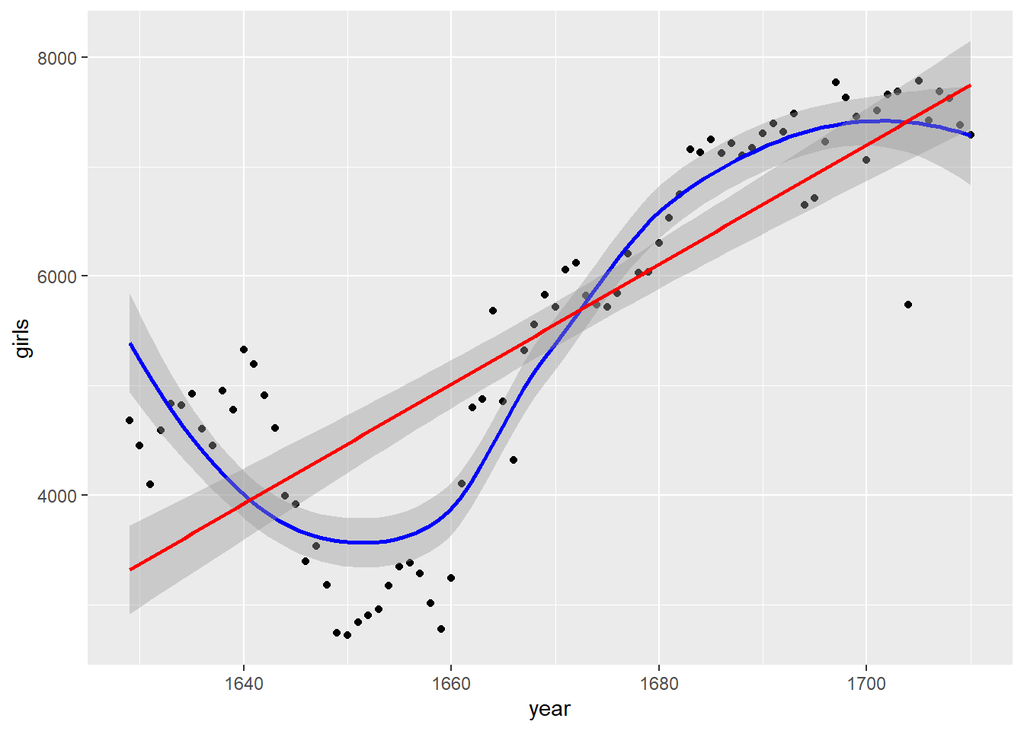

```r
ggplot(arbuthnot, aes(x = year, y = girls)) +
  geom_point() +
  geom_smooth(method = 'loess', formula = 'y ~ x', color = 'blue') +
  geom_smooth(method = 'lm', formula = 'y ~ x', color = 'red')
```

I plotted two trend functions over the scatterplot to get a sense of the trend.

First, the LEOSS function was used to closely follow the trend over time. It reveals declining numbers of girls baptized from the beginning of the series through ~1650, at which point the numbers begin to increase. The rate of increase continues before leveling off in ~1690.

Second, a linear regression function was used to get a sense of the broader trend, which is clearly positive. Despite the minor dips in the beginning of the series, generally, over time, the number of girls baptized increased.

### Exercise 3

Generate a plot of the proportion of boys born over time. What do you see?

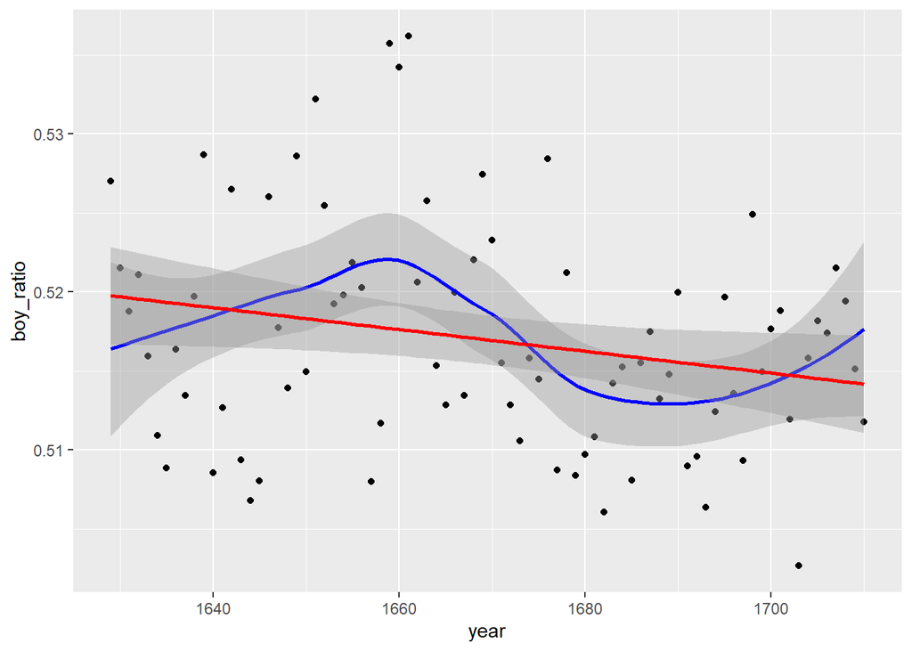

```r
arbuthnot <- arbuthnot %>%
  mutate(total = boys + girls,
         boy_ratio = boys / total)

ggplot(arbuthnot, aes(x = year, y = boy_ratio)) +
  geom_point() +
  geom_smooth(method = 'loess', formula = 'y ~ x', color = 'blue') +
  geom_smooth(method = 'lm', formula = 'y ~ x', color = 'red')
```

As before, we view two plots to get (i) a more granular view and (ii) a broader view.

The LEOSS function shows the proportion of boy baptisms increasing through ~1660, followed by a period of decline through ~1690, followed by another period of slower increase.

The LM function shows a slow decline in the proportion of boy to girl baptisms.

Both of these functions, however, do not appear to show a great fit to the data, which appears quite noisy. In fact, it is unclear that there is any real trend to pull from this series. However, we can see that in ALL years, the proportion remained above 50%.

### Exercise 4

What years are included in this data set? What are the dimensions of the data frame? What are the variable (column) names?

```r
data('present', package='openintro')
glimpse(present)
```

```
## Rows: 63
## Columns: 3
## $ year  <dbl> 1940, 1941, 1942, 1943, 1944, 1945, 1946, 1947, 1948, 1949, 1950…
## $ boys  <dbl> 1211684, 1289734, 1444365, 1508959, 1435301, 1404587, 1691220, 1…
## $ girls <dbl> 1148715, 1223693, 1364631, 1427901, 1359499, 1330869, 1597452, 1…
```

```r
tail(present, 1)
```

```
## # A tibble: 1 × 3
##    year    boys   girls
##   <dbl>   <dbl>   <dbl>
## 1  2002 2057979 1963747
```

The data shows birthrates from 1940 to 2002. The dimensions comprise 63 observations (rows) of 3 variables (columns). These three variables are year, boys born and girls born.

### Exercise 5

How do these counts compare to Arbuthnot’s? Are they of a similar magnitude?

```r
present %>%
  mutate(decade = year %/% 10 * 10,
         total = boys + girls
         ) %>%
  group_by(decade) %>%
  summarize(sum(total))
```

```
## # A tibble: 7 × 2
##   decade `sum(total)`
##    <dbl>        <dbl>
## 1   1940     30233147
## 2   1950     39985244
## 3   1960     38808409
## 4   1970     33308985
## 5   1980     37507077
## 6   1990     39860087
## 7   2000     12106473
```

```r
arbuthnot %>%
  mutate(decade = year %/% 10 * 10,
         total = boys + girls
         ) %>%
  group_by(decade) %>%
  summarize(sum(total))
```

```
## # A tibble: 10 × 2
##    decade `sum(total)`
##     <dbl>        <int>
##  1   1620         9901
##  2   1630        96452
##  3   1640        84234
##  4   1650        63485
##  5   1660       101734
##  6   1670       122505
##  7   1680       143026
##  8   1690       150055
##  9   1700       151903
## 10   1710        14928
```

The present dataset contains birth counts several orders of magnitude higher than those in the Arbuthnot dataset. This difference is expected, given the lower general population during Arbuthnot’s time versus recent history, the smaller geographic scope of his survey (London versus the entire US), and the fact that Arbuthnot’s survey focused on a proxy measure of birth rates (baptism rates).

### Exercise 6

Make a plot that displays the proportion of boys born over time. What do you see? Does Arbuthnot’s observation about boys being born in greater proportion than girls hold up in the U.S.? Include the plot in your response.

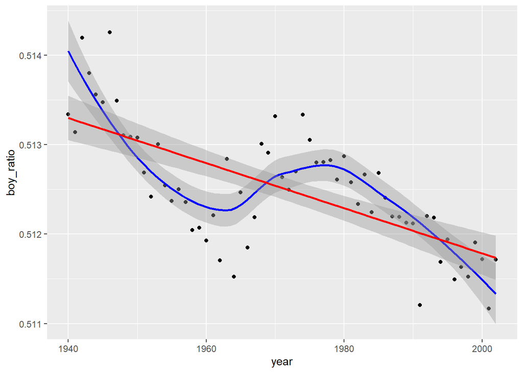

```r
present <- present %>%
  mutate(total = boys + girls,
         boy_ratio = boys / total)

ggplot(present, aes(x = year, y = boy_ratio)) +
  geom_point() +
  geom_smooth(method = 'loess', formula = 'y ~ x', color = 'blue') +
  geom_smooth(method = 'lm', formula = 'y ~ x', color = 'red')
```

Arbuthnot’s observation appears to hold true in the modern US, as all years show a proportion above 50%. That proportion, however, also shows a clear downward trend, despite being relatively noisy.

### Exercise 7

In what year did we see the most total number of births in the U.S.?

```r
# Approach from Lab
present %>%
  arrange(desc(total))
```

```
## # A tibble: 63 × 5
##     year    boys   girls   total boy_ratio
##    <dbl>   <dbl>   <dbl>   <dbl>     <dbl>
##  1  1961 2186274 2082052 4268326     0.512
##  2  1960 2179708 2078142 4257850     0.512
##  3  1957 2179960 2074824 4254784     0.512
##  4  1959 2173638 2071158 4244796     0.512
##  5  1958 2152546 2051266 4203812     0.512
##  6  1962 2132466 2034896 4167362     0.512
##  7  1956 2133588 2029502 4163090     0.513
##  8  1990 2129495 2028717 4158212     0.512
##  9  1991 2101518 2009389 4110907     0.511
## 10  1963 2101632 1996388 4098020     0.513
## # … with 53 more rows
```

```r
# Alternate Approach using Subsetting
present[present$total == max(present$total),]
```

```
## # A tibble: 1 × 5
##    year    boys   girls   total boy_ratio
##   <dbl>   <dbl>   <dbl>   <dbl>     <dbl>
## 1  1961 2186274 2082052 4268326     0.512
```

```r
# Alternate Approach using Filter
present %>%
  filter(present$total == max(present$total))
```

```
## # A tibble: 1 × 5
##    year    boys   girls   total boy_ratio
##   <dbl>   <dbl>   <dbl>   <dbl>     <dbl>
## 1  1961 2186274 2082052 4268326     0.512
```

The year with the most births in the US was 1961.